# Product Quality Based on Green and Dry Boards

JH

7/24/2015

# 1 Background

The eCambium trial to be run later in 2015 hopes to use green board density and stress wave velocity (SWV) to estimate product quality at individual log and site levels.

In the eCambium context, product quality equates to stiffness. In the grain direction wood is typically only 10% stiffer when dry compared to green.

Green board properties are to be measured using a Calibre Ecoustic device installed in Hyne’s Tumbarumba green mill. This device uses load cells to measure board weight and a hammer/microphone to measure stress wave velocity. These measures are combined with a dimensions from the USNR trimmer scanner to yield board green density which in turn is combined with SWV to yield an estimate of board MOE (currently $E = \rho v^2$). In situations where measurement quality is poor, a default MOE of 6.50 GPa is assigned. Currently, only weight, density and predicted MOE are written to the Ecoustic results file.

# 2 Hyne Dataset

SWI collected put 123 logs through Hyne’s Tumbarumba mill in 2014/15. The resulting dataset include green as well as dry board measures.

Associating boards with logs in the Hyne green mill makes use of:

- Calibre Ecoustic csv results file (collected after trimsaw)
- board LE imagery (collected before trimsaw)
- USNR database information (e.g. TRIMMER2.FlitchDetail)

```r
library(lattice)
library(gridExtra)
```

```r
library(RODBC)
ch = odbcConnect('Hyne',uid='sa',pwd="password12")
#
# BOARDS
#
B = sqlQuery(ch, "
            select
              m.flitchId, SWILogNumber,
               g.MOE [E.g],
               g.Density [den.g],
               m.swv [v.d],
               h.[Density_kg/m3] [den.d],
               h.[MOE.cltraw] [E.d],
               m.pith,
               m.wane,
               X_MOE/1000. [E.d.chh],
               X_Dens [den.d.chh]
            from
               (select flitchId, max(pith) pith, max(wane) wane, avg(swv) swv
                from manualMeas
                group by flitchId) m
             left join HyneDryBoards h on h.flitchId=m.flitchId
             left join ecoustic g on m.flitchId=g.flitchId
             left join CHHBoards c on m.flitchId=c.flitchId
             left join (
                select flitchId, max(SWILogNumber) SWILogNumber
                from boardEndImages i, barcode_image bi, boardEndBarcodes b
                where flitchId is not null and i.id=bi.imageId and bi.barcodeId=b.id group by flitchId
             ) f on f.flitchId=m.flitchId
             where g.MOE>0 and g.MOE<>6.5
             ")
B$pith_wane = paste("pith =",B$pith,"; wane =",B$wane)
B$E.d.hitman = B$v.d^2*B$den.d.chh/1e9
B$v.g = sqrt(B$E.g*1e9/B$den.g)
B$E.g.corrected = B$E.g
B$E.g.corrected[B$v.g>4000] = (B$v.g[B$v.g>4000]/2)^2*B$den.g[B$v.g>4000]/1e9
#
# LOGS
#
L = sqlQuery(ch, "
             select
               p.*,
               t.SWV [SWV],
               t.weight,
               3.141592654*4.9/3*(rL*rL+rS*rL+rS*rS) [volume.heart]
             from
               (select *
                from logs
                where SWILogNumber is not null
                and DateAndTime>'2014-08-31 00:00:00') p
               left join (select *
                          from logs
                          where SWILogNumber is not null
                          and DateAndTime<'2014-08-31 00:00:00') s
                 on s.SWILogNumber=p.SWILogNumber
               left join yardTrimmed t
                 on p.SWILogNumber=t.SWILogNumber
               left join yardUntrimmed u
                 on p.SWILogNumber=u.SWILogNumber
               left join (select
                            l.SWILogNumber,
                            l.heartwoodDiameter_mm/2000 rL,
                            s.heartwoodDiameter_mm/2000 rS
                          from
                            logends l,
                            logends s
                          where
                            s.SWILogNumber=l.SWILogNumber
                            and s.logEnd='S'
                            and l.logEnd='L') h
                 on h.SWILogNumber=p.SWILogNumber
             order by p.SWILogNumber")
for (i in 1:nrow(L)) {
  ii = !is.na(B$SWILogNumber) & B$SWILogNumber==L[i,"SWILogNumber"]
  ii = ii & is.finite(B$E.g.corrected) & is.finite(B$E.d)
  L[i,"nboards"]=sum(ii)
  L[i,"avgBoardMOE.g"]=mean(B$E.g.corrected[ii],na.rm=TRUE)
  L[i,"avgBoardMOE.d"]=mean(B$E.d[ii],na.rm=TRUE)
}
```

# 3 Board Level Comparisons

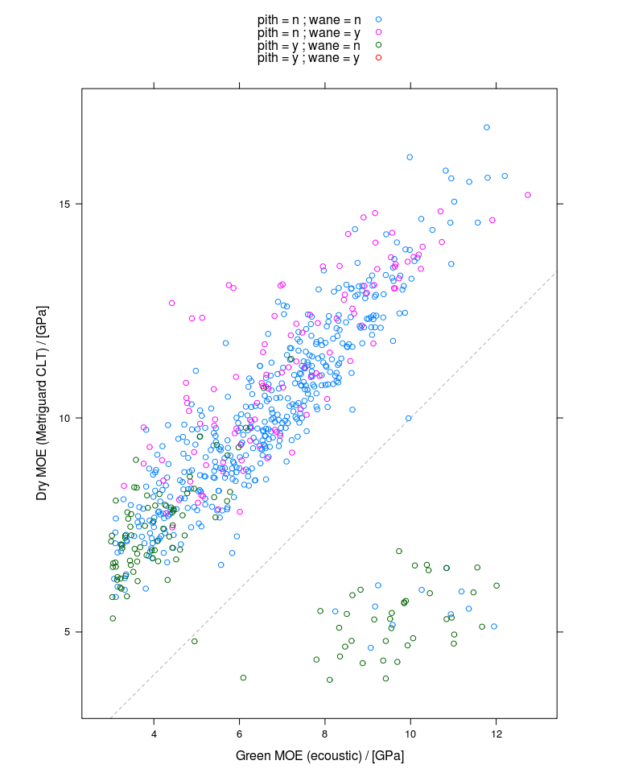

```r
xyplot(E.d ~ E.g, B,
       group=pith_wane,
       auto.key=TRUE,
       panel=function(x,y,...) {
          panel.abline(c(0,1), col='grey70', lty=2)
          panel.xyplot(x,y,...)
       },
       xlab="Green MOE (ecoustic) / [GPa]",
       ylab="Dry MOE (Metriguard CLT) / [GPa]",
       aspect='iso')
```

After correction:

```r
summary(m.board <- lm(E.d ~ E.g.corrected, B))
```

```
##
## Call:
## lm(formula = E.d ~ E.g.corrected, data = B)
##
## Residuals:
##     Min      1Q  Median      3Q     Max
## -6.3702 -0.6218 -0.0749  0.4955  4.7424
##
## Coefficients:
##               Estimate Std. Error t value Pr(>|t|)
## (Intercept)    3.41549    0.11148   30.64   <2e-16 ***
## E.g.corrected  1.02381    0.01724   59.38   <2e-16 ***
## ---
## Signif. codes:  0 '***' 0.001 '**' 0.01 '*' 0.05 '.' 0.1 ' ' 1
##
## Residual standard error: 0.9826 on 666 degrees of freedom
##   (227 observations deleted due to missingness)
## Multiple R-squared:  0.8411, Adjusted R-squared:  0.8409
## F-statistic:  3525 on 1 and 666 DF,  p-value: < 2.2e-16
```

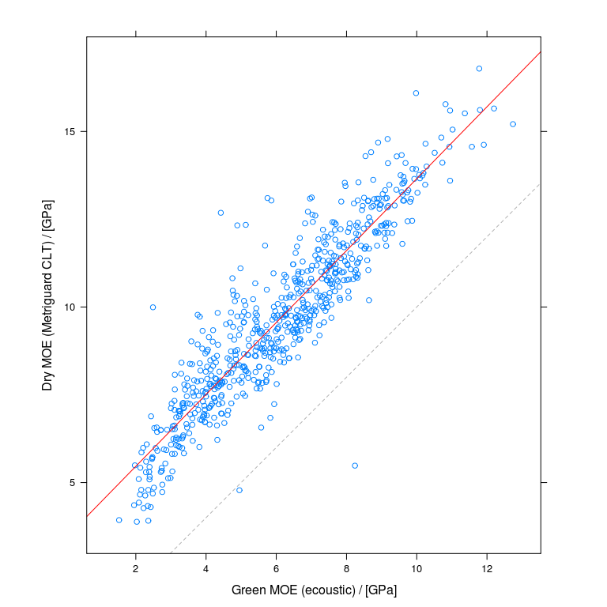

```r
xyplot(E.d ~ E.g.corrected, B,
       panel=function(x,y,...) {
          panel.abline(c(0,1), col='grey70', lty=2)
          panel.xyplot(x,y,...)
          panel.abline(coef(m.board), col='red')
       },
       xlab="Green MOE (ecoustic) / [GPa]",
       ylab="Dry MOE (Metriguard CLT) / [GPa]",
       aspect='iso')
```

The fitted model suggests there is an offset between green and dry MOE but little in the way of a proportional increase (perhaps the increase in stiffness due to drying is offset by the decrease associated with static rather than dynamic measurement method). The offset is likely due to weights being systematically high (perhaps incorrectly calibrated load cells), an idea supported by a number of boards having green densities greater than 1200 kg/m^3.

Clearly, if the eCambium trial needs to convert green Ecoustic measurements to *absolute* dry MOE some sort of calibration dataset will be required, but in all likelihood, green MOE can be used as a *relative* measure directly, with an RMSE of around 1 GPa.

# 4 Log Level Comparisons

Incomplete records (i.e. boards missing either green or dry MOE) are excluded from the analysis.

```r
summary(m.log <- lm(avgBoardMOE.d ~ avgBoardMOE.g, L))
```

```
##
## Call:
## lm(formula = avgBoardMOE.d ~ avgBoardMOE.g, data = L)
##
## Residuals:
##      Min       1Q   Median       3Q      Max
## -1.56240 -0.49694 -0.06171  0.43291  2.07844
##
## Coefficients:
##               Estimate Std. Error t value Pr(>|t|)
## (Intercept)    2.87928    0.27118   10.62   <2e-16 ***
## avgBoardMOE.g  1.12394    0.04484   25.06   <2e-16 ***
## ---
## Signif. codes:  0 '***' 0.001 '**' 0.01 '*' 0.05 '.' 0.1 ' ' 1
##
## Residual standard error: 0.6728 on 119 degrees of freedom
##   (2 observations deleted due to missingness)
## Multiple R-squared:  0.8407, Adjusted R-squared:  0.8394
## F-statistic: 628.1 on 1 and 119 DF,  p-value: < 2.2e-16
```

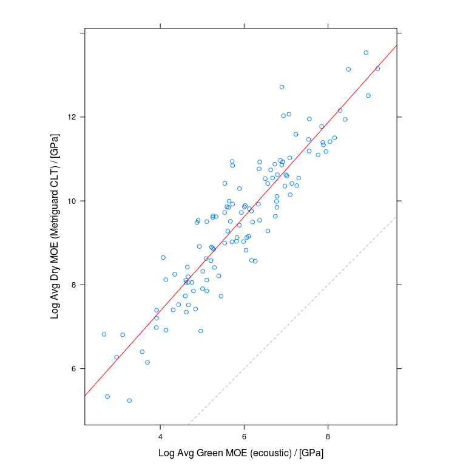

```r
xyplot(avgBoardMOE.d ~ avgBoardMOE.g, L,
       panel=function(x,y,...) {
          panel.abline(c(0,1), col='grey70', lty=2)
          panel.xyplot(x,y,...)
          panel.abline(coef(m.log), col='red')
       },
       xlab="Log Avg Green MOE (ecoustic) / [GPa]",
       ylab="Log Avg Dry MOE (Metriguard CLT) / [GPa]",
       aspect='iso')
```

$r^2 = 0.84$, RMSE=0.7 GPa.

# 5 Site Level Comparisons

Site information is not directly available in the Hyne dataset. Instead lets look at results averaged over sets of 30 logs.

```r
S = data.frame()
for (site in 1:100) {
  ii = B$SWILogNumber%in%sample(100:223, 30)
  S=rbind(S,data.frame(SWILogNumber=site,
                       avgBoardMOE.g=mean(B$E.g.corrected[ii], na.rm=TRUE),
                       avgBoardMOE.d=mean(B$E.d[ii], na.rm=TRUE)
                       ))
}
summary(m.site <- lm(avgBoardMOE.d ~ avgBoardMOE.g, S))
```

```
##
## Call:
## lm(formula = avgBoardMOE.d ~ avgBoardMOE.g, data = S)
##
## Residuals:
##       Min        1Q    Median        3Q       Max
## -0.302039 -0.073489 -0.008639  0.076402  0.292635
##
## Coefficients:
##               Estimate Std. Error t value Pr(>|t|)
## (Intercept)    2.23723    0.37738   5.928 4.58e-08 ***
## avgBoardMOE.g  1.23309    0.06254  19.716  < 2e-16 ***
## ---
## Signif. codes:  0 '***' 0.001 '**' 0.01 '*' 0.05 '.' 0.1 ' ' 1
##
## Residual standard error: 0.1248 on 98 degrees of freedom
## Multiple R-squared:  0.7987, Adjusted R-squared:  0.7966
## F-statistic: 388.7 on 1 and 98 DF,  p-value: < 2.2e-16
```

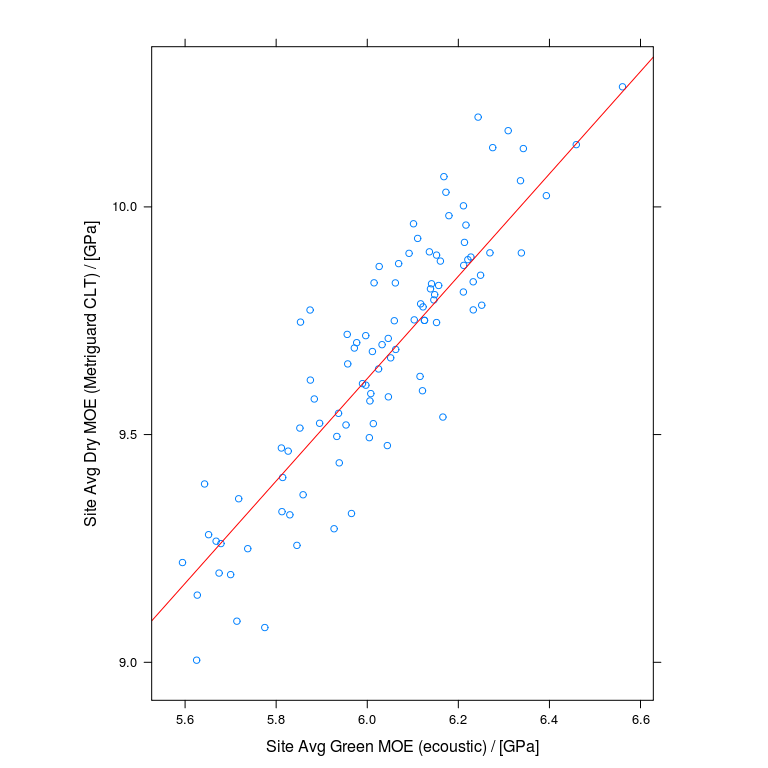

```r
xyplot(avgBoardMOE.d ~ avgBoardMOE.g, S,
       panel=function(x,y,...) {
          panel.abline(c(0,1), col='grey70', lty=2)
          panel.xyplot(x,y,...)
          panel.abline(coef(m.log), col='red')
       },
       xlab="Site Avg Green MOE (ecoustic) / [GPa]",
       ylab="Site Avg Dry MOE (Metriguard CLT) / [GPa]",
       aspect='iso')
```

# 6 Predicting Log Average Board Stiffness

Slightly off-topic, but useful in case of dire failures in-mill…

In cases where log average board stiffness is a sufficient measure of product quality (i.e. when less interested in relative distribution of board stiffnesses and more interested in the average value) then log level measures can be used instead of using green board MOE to predict dry board MOE. How well can log average board MOE be predicted from log level measurements?

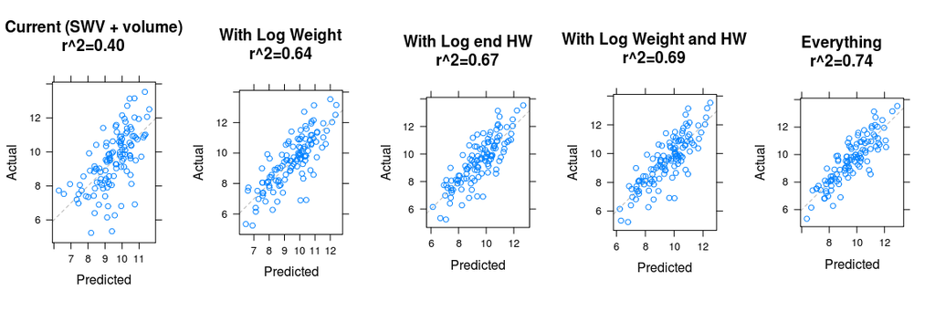

```
##
## Call:
## lm(formula = avgBoardMOE.d ~ SWV + volume, data = L)
##
## Residuals:
##     Min      1Q  Median      3Q     Max
## -4.0733 -0.6464  0.1035  0.7802  2.6902
##
## Coefficients:
##               Estimate Std. Error t value Pr(>|t|)
## (Intercept) -6.6725614  1.8274862  -3.651 0.000392 ***
## SWV          0.0046388  0.0005222   8.883 9.21e-15 ***
## volume       2.0984594  0.6394554   3.282 0.001361 **
## ---
## Signif. codes:  0 '***' 0.001 '**' 0.01 '*' 0.05 '.' 0.1 ' ' 1
##
## Residual standard error: 1.311 on 117 degrees of freedom
##   (3 observations deleted due to missingness)
## Multiple R-squared:  0.4038, Adjusted R-squared:  0.3936
## F-statistic: 39.62 on 2 and 117 DF,  p-value: 7.261e-14
##
##
## Call:
## lm(formula = avgBoardMOE.d ~ SWV + density + weight, data = L)
##
## Residuals:
##     Min      1Q  Median      3Q     Max
## -3.5067 -0.5070  0.0576  0.4704  2.4186
##
## Coefficients:
##               Estimate Std. Error t value Pr(>|t|)
## (Intercept) -2.026e+01  2.113e+00  -9.588  < 2e-16 ***
## SWV          5.441e-03  4.153e-04  13.101  < 2e-16 ***
## density      1.197e-02  1.461e-03   8.198 3.71e-13 ***
## weight       1.636e-03  5.219e-04   3.135  0.00218 **
## ---
## Signif. codes:  0 '***' 0.001 '**' 0.01 '*' 0.05 '.' 0.1 ' ' 1
##
## Residual standard error: 1.018 on 116 degrees of freedom
##   (3 observations deleted due to missingness)
```

[output cut: 68 more lines]

```
## m_a2         -5.186e-01  2.818e-01  -1.840 0.068851 .
## m_taper       2.327e+00  1.345e+00   1.729 0.086951 .
## m_whorliness -8.820e-01  3.346e-01  -2.636 0.009781 **
## m_sweep1     -3.135e-01  1.502e-01  -2.087 0.039499 *
## m_sweep2      1.411e+00  9.964e-01   1.416 0.159961
## weight        1.725e-02  5.806e-03   2.971 0.003753 **
## hw.vfrac     -4.417e+00  1.438e+00  -3.070 0.002780 **
## volume       -7.666e+01  2.857e+01  -2.683 0.008587 **
## ---
## Signif. codes:  0 '***' 0.001 '**' 0.01 '*' 0.05 '.' 0.1 ' ' 1
##
## Residual standard error: 0.8835 on 96 degrees of freedom
##   (13 observations deleted due to missingness)
## Multiple R-squared:  0.7433, Adjusted R-squared:  0.7085
## F-statistic: 21.38 on 13 and 96 DF,  p-value: < 2.2e-16
```

```r
myplot=function (m, lbl) {
  print(s<-summary(m))
  xyplot(m$model$avgBoardMOE.d ~ predict(m),
         panel=function(x,y,...) {
           panel.abline(c(0,1), col='grey70', lty=2)
           panel.xyplot(x,y,...)},
          aspect='iso',
         xlab='Predicted', ylab='Actual',
         main=sprintf('%s\nr^2=%0.2f',lbl,s$r.squared))
         #main=lbl, sub=expression(r^2==s$r.squared))
}
grid.arrange(myplot(m.best.current, lbl="Current (SWV + volume)"),
             myplot(m.best.withWeight, lbl="With Log Weight"),
             myplot(m.best.withHW, lbl="With Log end HW"),
             myplot(m.best.withWeightHW, lbl="With Log Weight and HW"),
             myplot(m.best, lbl="Everything"),
             nrow=1,
             as.table=TRUE)
```

With log weight and heartwood, $r^2 = 0.7$, RMSE=0.9 GPa. Prediction quality similar to using green board MOE!

# 7 Conclusions and Recommendations

Ecoustic green MOE should do the job, particularly post-correction.

Previously collected green and dry MOE data should be helpful when testing for significant differences between log and sites.

Predicting log average board MOE from log measures alone is a credible alternative, particularly if log weight is known.

Some recommendations:

1. The calibre output file be amended to include as-measured SWV (even if silly) as well as predicted MOE (retaining 6.5 GPa default). Ideally, some measure of confidence in the SWV should also be included.
2. The ecoustic load cell calibrations be checked immediately before (and again after?) the trial is run
3. Trim logs to random (but known) lengths (±5 cm) to assist assigning boards to logs based on trimmer scanner data. Easiest if done within site batches.
4. Put some effort into devising a quick’n’easy method of determining log weight.
5. Ensure log volume and shape data collected.

If we really believed in prediction from log measures, could the trial be expanded without significantly increasing cost to include more logs, but processing only a subset?